# Panel Data - Linear Mixed Effect Models

Michael Winton

7/30/2018

## Mixed Effect Models

In a *mixed model* for panel data, we add one or more *random effects* in order to give structure to the error term. This is in contract to OLS regression, where you don’t want structure in your error terms. By adding individual-specific dummy variables (intercepts) to our model, we avoid violating the independence requirement. However, its still possible to have omitted variable bias if important variables which are correlated with our explanatory variables are missing altogether from our model.

> ASIDE: what econometrics calls “panel models” is also referred to in other fields as “mixed effects, hierarchical models” or “models for longitudinal data”.

### Example: modeling variations in human speech (pitch)

In speech recognition, it’s common to model pitch as a function of age:

$$pitch_i \sim age_i + \epsilon_i$$
Here, $age_i$ is a fixed effect, and $\epsilon_i$ is the error term that represents random factors we can’t control for experimentally. We will look at data from a Korean experiment, wherein multiple subjects (male and female) were asked to say certain responses in both formal and informal settings.

```r
politeness <- read.csv(file='politeness_data.csv')
str(politeness)
```

```
## 'data.frame':    84 obs. of  5 variables:
##  $ subject  : Factor w/ 6 levels "F1","F2","F3",..: 1 1 1 1 1 1 1 1 1 1 ...
##  $ gender   : Factor w/ 2 levels "F","M": 1 1 1 1 1 1 1 1 1 1 ...
##  $ scenario : int  1 1 2 2 3 3 4 4 5 5 ...
##  $ attitude : Factor w/ 2 levels "inf","pol": 2 1 2 1 2 1 2 1 2 1 ...
##  $ frequency: num  213 204 285 260 204 ...
```

```r
head(politeness)
```

|  | subject | gender | scenario | attitude | frequency |
| --- | --- | --- | --- | --- | --- |
| 1 | F1 | F | 1 | pol | 213.3 |
| 2 | F1 | F | 1 | inf | 204.5 |
| 3 | F1 | F | 2 | pol | 285.1 |
| 4 | F1 | F | 2 | inf | 259.7 |
| 5 | F1 | F | 3 | pol | 203.9 |
| 6 | F1 | F | 3 | inf | 286.9 |

```r
summary(politeness) # note there's one NA value for frequency
```

```
##  subject gender    scenario attitude   frequency
##  F1:14   F:42   Min.   :1   inf:42   Min.   : 82.2
##  F2:14   M:42   1st Qu.:2   pol:42   1st Qu.:131.6
##  F3:14          Median :4            Median :203.9
##  M3:14          Mean   :4            Mean   :193.6
##  M4:14          3rd Qu.:6            3rd Qu.:248.6
##  M7:14          Max.   :7            Max.   :306.8
##                                      NA's   :1
```

```r
table(politeness$subject)
```

```
##
## F1 F2 F3 M3 M4 M7
## 14 14 14 14 14 14
```

```r
table(politeness$scenario)
```

```
##
##  1  2  3  4  5  6  7
## 12 12 12 12 12 12 12
```

```r
table(politeness$gender)
```

```
##
##  F  M
## 42 42
```

```r
table(politeness$attitude)
```

```
##
## inf pol
##  42  42
```

We note that there’s a balanced panel, and we have one observation with a missing dependent variable.

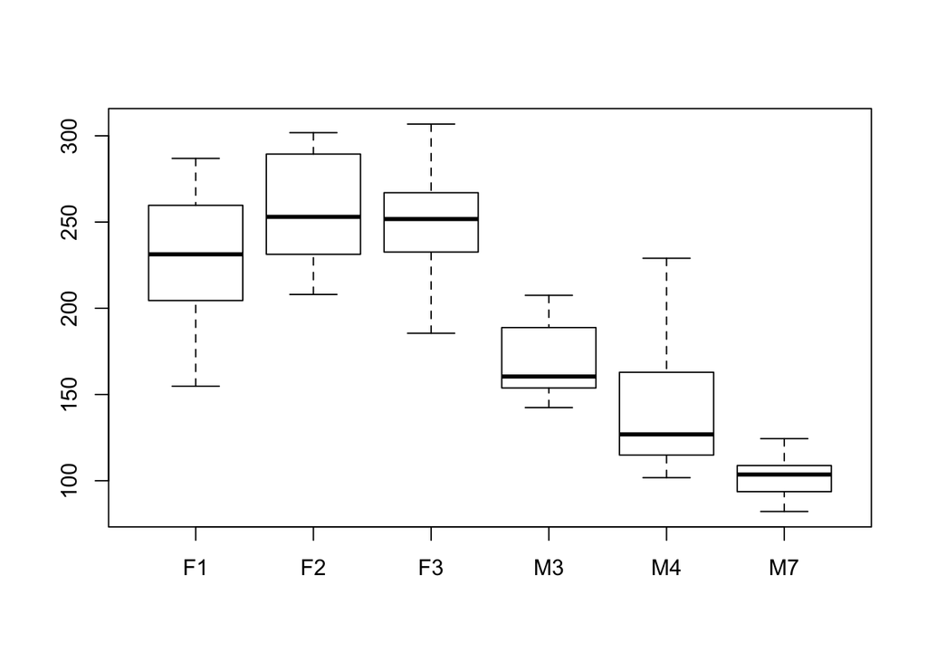

```r
boxplot(frequency ~ subject, data=politeness)
```

As expected, we see females generally have higher pitched voices than males, so we need to update our model to incorporate gender:

$$pitch_i \sim politeness_i + gender_i + \epsilon_i$$

We also observe indidual variation between voices. In a linear mixed effect model, we would model this individual-specific factor as a *random effect*. This random effect is an individual-specific intercept representing each person’s baseline pitch, and can be estimated with a linear mixed model. Thus, our updated model is:

$$pitch_i \sim politeness_i + gender_i + (1 | subject) + \epsilon_i$$
Importantly, this framework resolves the interdependence issues that stem from having multiple response from the same subjects (which would be the problem with traditional OLS modeling).

In this study, the specific scenario prompts were different (e.g. asking a favor, or apologizing for being late).

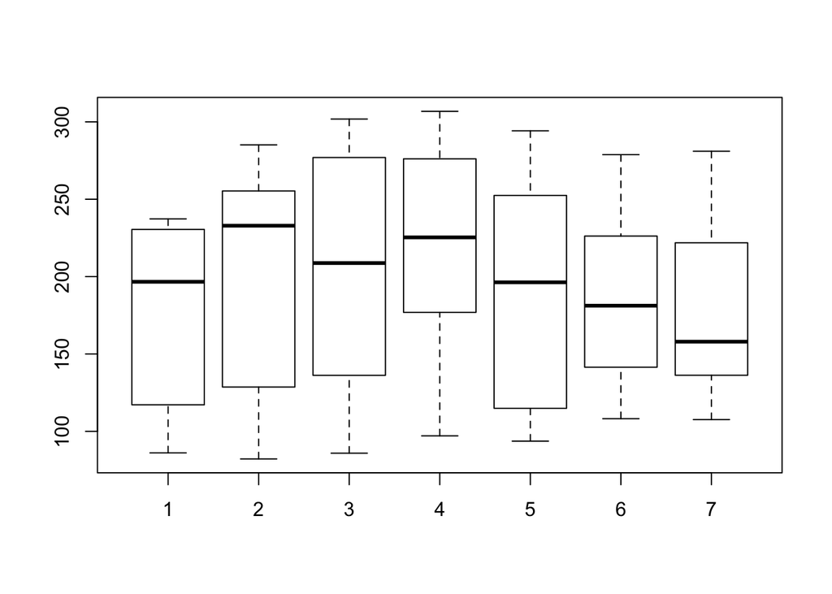

```r
boxplot(frequency ~ scenario, data=politeness)
```

We need to add random effects because of this scenario-dependent variation, too. These are also required in order to avoid violating the independence requirement. Our updated model becomes:

$$pitch_i \sim politeness_i + gender_i + (1 | subject) + (1 | scenario) + \epsilon_i$$
So, now we have different intercepts for each subject, as well as for each scenario. Our model now accounts for all known interdependencies. We can also observe the boxplots by gender and attitude (ie. polite or informal).

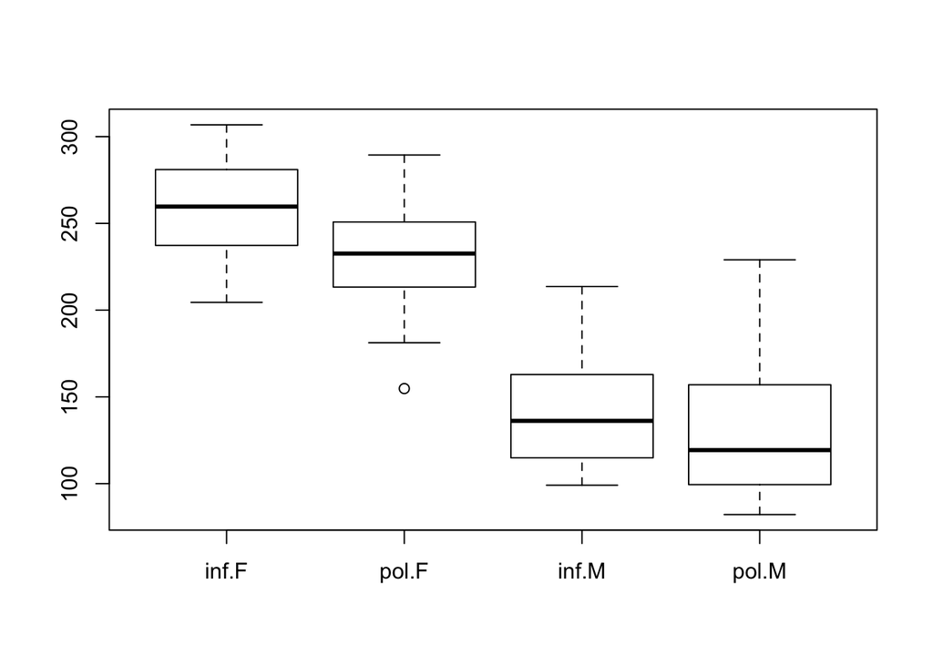

```r
boxplot(frequency ~ attitude + gender, data=politeness)
```

## Modeling in R

In R, we use the `lme4` (or `nmle`) packages for linear mixed models.

```r
mod_lmm <- lmer(frequency ~ attitude + (1|subject) + (1|scenario), data=politeness)
summary(mod_lmm)
```

```
## Linear mixed model fit by REML ['lmerMod']
## Formula: frequency ~ attitude + (1 | subject) + (1 | scenario)
##    Data: politeness
##
## REML criterion at convergence: 793.5
##
## Scaled residuals:
##    Min     1Q Median     3Q    Max
## -2.201 -0.582 -0.064  0.563  3.439
##
## Random effects:
##  Groups   Name        Variance Std.Dev.
##  scenario (Intercept)  219     14.8
##  subject  (Intercept) 4015     63.4
##  Residual              646     25.4
## Number of obs: 83, groups:  scenario, 7; subject, 6
##
## Fixed effects:
##             Estimate Std. Error t value
## (Intercept)   202.59      26.75    7.57
## attitudepol   -19.69       5.58   -3.53
##
## Correlation of Fixed Effects:
##             (Intr)
## attitudepol -0.103
```

Note that R reports the variance of the random effect intercepts for subjects and scenarios, rather than the individual numbers. The scenario induces much less variability than the human subjects do. The residual term corresponds to $\epsilon_i$ in our model - variability not explained by either the scenario or subject, but some other factor.

We also see the estimated coefficients for the fixed effect of attitude; from the t-value, we see it’s highly statistically significant. When switching from informal to polite speech, pitch drops by -19.7 Hz on average. Also note that the intercept in this model didn’t take into account gender, so it’s the average person’s baseline pitch (not particularly useful).

```r
mod_lmm2 <- lmer(frequency ~ attitude + gender + (1|subject) + (1|scenario), data=politeness)
summary(mod_lmm2)
```

```
## Linear mixed model fit by REML ['lmerMod']
## Formula: frequency ~ attitude + gender + (1 | subject) + (1 | scenario)
##    Data: politeness
##
## REML criterion at convergence: 775.5
##
## Scaled residuals:
##    Min     1Q Median     3Q    Max
## -2.259 -0.624 -0.077  0.539  3.480
##
## Random effects:
##  Groups   Name        Variance Std.Dev.
##  scenario (Intercept) 219      14.8
##  subject  (Intercept) 616      24.8
##  Residual             646      25.4
## Number of obs: 83, groups:  scenario, 7; subject, 6
##
## Fixed effects:
##             Estimate Std. Error t value
## (Intercept)   256.85      16.12   15.94
## attitudepol   -19.72       5.58   -3.53
## genderM      -108.52      21.01   -5.16
##
## Correlation of Fixed Effects:
##             (Intr) atttdp
## attitudepol -0.173
## genderM     -0.652  0.004
```

In this model, the intercept (256.85) represents the baseline female voice, and the baseline male voice is 109 Hz lower, on average. Also observe that the intercept for subject dropped significantly in this model, as much of the variation is now accounted for by gender.

## Estimating p-value via Likelihood Ratio tests

In order to calculate a p-value, we need to run the model twice - with and without the factor in question, setting the parameter `REML=FALSE`. (REML is an alternative to log-likehlihood estimation.)

```r
mod_lmm_h0 <- lmer(frequency ~ gender + (1|subject) + (1|scenario), data=politeness, REML=FALSE)
mod_lmm_ha <- lmer(frequency ~ attitude + gender + (1|subject) + (1|scenario), data=politeness, REML=FALSE)
anova(mod_lmm_h0, mod_lmm_ha)
```

|  | Df | AIC | BIC | logLik | deviance | Chisq | Chi Df | Pr(>Chisq) |
| --- | --- | --- | --- | --- | --- | --- | --- | --- |
| mod_lmm_h0 | 5 | 816.7 | 828.8 | -403.4 | 806.7 | NA | NA | NA |
| mod_lmm_ha | 6 | 807.1 | 821.6 | -397.6 | 795.1 | 11.62 | 1 | 0.0006532 |

This confirms a highly statistically significant result. Politeness affected pitch ($\chi^2(1)=11.6, p=0.00065$), lowering it by 19.7 Hz (std error = +/- 5.58 Hz).

We could also explore for an interaction term between gender and attitude (does one gender respond more strongly than the other to changes in politeness).

```r
mod_lmm_h0 <- lmer(frequency ~ gender + (1|subject) + (1|scenario), data=politeness, REML=FALSE)
mod_lmm_ha <- lmer(frequency ~ attitude + gender + attitude:gender + (1|subject) + (1|scenario), data=politeness, REML=FALSE)
anova(mod_lmm_h0, mod_lmm_ha)
```

|  | Df | AIC | BIC | logLik | deviance | Chisq | Chi Df | Pr(>Chisq) |
| --- | --- | --- | --- | --- | --- | --- | --- | --- |
| mod_lmm_h0 | 5 | 816.7 | 828.8 | -403.4 | 806.7 | NA | NA | NA |
| mod_lmm_ha | 7 | 807.1 | 824.0 | -396.6 | 793.1 | 13.61 | 2 | 0.001106 |

```r
summary(mod_lmm_ha)
```

```
## Linear mixed model fit by maximum likelihood  ['lmerMod']
## Formula:
## frequency ~ attitude + gender + attitude:gender + (1 | subject) +
##     (1 | scenario)
##    Data: politeness
##
##      AIC      BIC   logLik deviance df.resid
##    807.1    824.0   -396.6    793.1       76
##
## Scaled residuals:
##    Min     1Q Median     3Q    Max
## -2.168 -0.556 -0.063  0.510  3.390
##
## Random effects:
##  Groups   Name        Variance Std.Dev.
##  scenario (Intercept) 205      14.3
##  subject  (Intercept) 419      20.5
##  Residual             620      24.9
## Number of obs: 83, groups:  scenario, 7; subject, 6
##
## Fixed effects:
##                     Estimate Std. Error t value
## (Intercept)           260.69      14.09   18.51
## attitudepol           -27.40       7.68   -3.57
## genderM              -116.20      18.39   -6.32
## attitudepol:genderM    15.57      10.94    1.42
##
## Correlation of Fixed Effects:
##             (Intr) atttdp gendrM
## attitudepol -0.273
## genderM     -0.653  0.209
## atttdpl:gnM  0.192 -0.702 -0.293
```

Again, we see a statistically significant result (p=0.0011) with men’s voices dropping less on average (-27.40 + 15.57 Hz) than women’s (-27.40 Hz).

## Random Intercepts vs. Random Slopes

The above models were all considered random intercept models, because the fixed effects are the same for all subjects and scenarios. We can confirm that by looking at the coefficients:

```r
coef(mod_lmm_ha)
```

```
## $scenario
##   (Intercept) attitudepol genderM attitudepol:genderM
## 1       247.2       -27.4  -116.2               15.57
## 2       267.2       -27.4  -116.2               15.57
## 3       272.0       -27.4  -116.2               15.57
## 4       281.2       -27.4  -116.2               15.57
## 5       258.7       -27.4  -116.2               15.57
## 6       248.8       -27.4  -116.2               15.57
## 7       249.7       -27.4  -116.2               15.57
##
## $subject
##    (Intercept) attitudepol genderM attitudepol:genderM
## F1       247.2       -27.4  -116.2               15.57
## F2       270.8       -27.4  -116.2               15.57
## F3       264.1       -27.4  -116.2               15.57
## M3       288.2       -27.4  -116.2               15.57
## M4       266.1       -27.4  -116.2               15.57
## M7       227.8       -27.4  -116.2               15.57
##
## attr(,"class")
## [1] "coef.mer"
```

If we feel it’s appropriate to account for different scenarios eliciting more or less politeness than others, we would need random slopes, too. In a *random slope model*, both intercepts and slopes are allowed to vary with the subject or scenario. This is very useful in practice, and different people often have different magnitudes of reaction to various stimuli.

To model this in R, we specify, for example, `(1 + attitude | scenario)` which tells R to expect a different intercept per scenario, as well as a different slope in attitude per scenario.

```r
mod_rsm <- lmer(frequency ~ attitude + gender + (1 + attitude | subject) +
                  (1 + attitude | scenario), data=politeness, REML=FALSE)
summary(mod_rsm)
```

```
## Linear mixed model fit by maximum likelihood  ['lmerMod']
## Formula: frequency ~ attitude + gender + (1 + attitude | subject) + (1 +
##     attitude | scenario)
##    Data: politeness
##
##      AIC      BIC   logLik deviance df.resid
##    814.9    839.1   -397.4    794.9       73
##
## Scaled residuals:
##    Min     1Q Median     3Q    Max
## -2.195 -0.669 -0.079  0.526  3.425
##
## Random effects:
##  Groups   Name        Variance Std.Dev. Corr
##  scenario (Intercept) 182.08   13.49
##           attitudepol  31.26    5.59    0.22
##  subject  (Intercept) 392.47   19.81
##           attitudepol   1.71    1.31    1.00
##  Residual             627.88   25.06
## Number of obs: 83, groups:  scenario, 7; subject, 6
##
## Fixed effects:
##             Estimate Std. Error t value
## (Intercept)   257.99      13.53   19.07
## attitudepol   -19.75       5.92   -3.33
## genderM      -110.80      17.51   -6.33
##
## Correlation of Fixed Effects:
##             (Intr) atttdp
## attitudepol -0.105
## genderM     -0.647  0.003
```

In the summary output, we see that the variance is reported now for slopes as well as intercepts. We can also look at the individual coefficients for both scenario as well as subject:

```r
coef(mod_rsm)
```

```
## $scenario
##   (Intercept) attitudepol genderM
## 1       245.3      -20.44  -110.8
## 2       263.3      -15.94  -110.8
## 3       269.1      -20.63  -110.8
## 4       276.8      -16.30  -110.8
## 5       256.1      -19.41  -110.8
## 6       246.9      -21.95  -110.8
## 7       248.5      -23.56  -110.8
##
## $subject
##    (Intercept) attitudepol genderM
## F1       243.8      -20.68  -110.8
## F2       266.7      -19.17  -110.8
## F3       260.1      -19.60  -110.8
## M3       285.7      -17.92  -110.8
## M4       264.2      -19.34  -110.8
## M7       227.4      -21.77  -110.8
##
## attr(,"class")
## [1] "coef.mer"
```

Because the coefficients are all of the same sign, and are quite similar in magnitude, we do see the same general tendencies of voice pitch to drop when shifting from informal to polite speech.

Now, calculate the p-value. Because the full model includes random slope terms, the null hypothesis needs them, too, even though the `attitude` variable is removed from the null model.

```r
mod_rsm_h0 <- lmer(frequency ~ gender + (1 + attitude | subject) +
                  (1 + attitude | scenario), data=politeness, REML=FALSE)
mod_rsm_ha <- lmer(frequency ~ attitude + gender + (1 + attitude | subject) +
                  (1 + attitude | scenario), data=politeness, REML=FALSE)
anova(mod_rsm_h0, mod_rsm_ha)
```

|  | Df | AIC | BIC | logLik | deviance | Chisq | Chi Df | Pr(>Chisq) |
| --- | --- | --- | --- | --- | --- | --- | --- | --- |
| mod_rsm_h0 | 9 | 819.6 | 841.4 | -400.8 | 801.6 | NA | NA | NA |
| mod_rsm_ha | 10 | 814.9 | 839.1 | -397.4 | 794.9 | 6.708 | 1 | 0.009597 |

We conclude that just as in the random intercept model, in this random slope model, there is a statistically significant effect of attitude (informal vs. polite) on pitch of speech.